# R Data Scientist Track - Data Camp

## ==== R packages ====

search() install.packages(“ggvis”) library(“ggvis”) search()

require()  
install.packages(“ggplot2”) library(ggplot2) qplot()

# Load the ggplot2 package library(ggplot2)

# Retry the qplot() function qplot(mtcars$wt, mtcars$hp)

# Check out the currently attached packages again search()

# The vector pioneers has already been created for you pioneers <- c(“GAUSS:1777”, “BAYES:1702”, “PASCAL:1623”, “PEARSON:1857”) pioneers # Split names from birth year split_math <- strsplit(pioneers, split = “:”) split_math # Convert to lowercase strings: split_low split_low <- lapply(split_math,tolower)

# Take a look at the structure of split_low str(split_low)

# Code from previous exercise: pioneers <- c(“GAUSS:1777”, “BAYES:1702”, “PASCAL:1623”, “PEARSON:1857”) pioneers split <- strsplit(pioneers, split = “:”) split split_low <- lapply(split, tolower) split_low # Write function select_first() select_first <- function(x) { x[1] } ## ==== Apply ==== # Apply select_first() over split_low: names names <- lapply(split_low,select_first) names # Write function select_second() select_second <- function(x){ x[2] }

# Apply select_second() over split_low: years years <- lapply(split_low,select_second)  
years

# split_low has been created for you split_low

# Transform: use anonymous function inside lapply names <- lapply(split_low, function(x){x[1]}) names # Transform: use anonymous function inside lapply

years <- lapply(split_low, function(x){x[2]}) years

# Definition of split_low pioneers <- c(“GAUSS:1777”, “BAYES:1702”, “PASCAL:1623”, “PEARSON:1857”) split <- strsplit(pioneers, split = “:”) split_low <- lapply(split, tolower)

# Generic select function select_el <- function(x, index) { x[index] }

# Use lapply() twice on split_low: names and years names <- lapply(split_low,select_el,1) names years <- lapply(split_low,select_el,2) years

str(TRUE) lapply(list(1,“a”, TRUE), str)

split_low

# Temp temp <- list(c(3, 7, 9, 6, -1), c(6, 9, 12, 13, 5), c(4, 8, 3, -1, -3),c(1, 4, 7, 2, -2), c(5, 7, 9, 4, 2), c(-3, 5, 8, 9, 4), c(3, 6, 9, 4, 1))

# temp has already been defined in the workspace temp str(temp) # Use lapply() to find each day’s minimum temperature lapply(temp,min)

# Use sapply() to find each day’s minimum temperature sapply(temp,min)

# Use lapply() to find each day’s maximum temperature lapply(temp,max)

# Use sapply() to find each day’s maximum temperature sapply(temp,max)

# temp is already defined in the workspace temp # Finish function definition of extremes_avg extremes_avg <- function(x) { ( min(x) + max(x) ) / 2 }

# Apply extremes_avg() over temp using sapply() sapply(temp,extremes_avg)

# Apply extremes_avg() over temp using lapply() lapply(temp,extremes_avg)

# temp is already available in the workspace temp # Create a function that returns min and max of a vector: extremes extremes <- function(x) { c(min = min(x), max = max(x)) } extremes(temp) # Apply extremes() over temp with sapply() sapply(temp,extremes)

# Apply extremes() over temp with lapply() lapply(temp,extremes)

# temp is already prepared for you in the workspace temp # Definition of below_zero() below_zero <- function(x) { return(x[x < 0]) } below_zero(c(4,5,-3,6)) # Apply below_zero over temp using sapply(): freezing_s freezing_s <- sapply(temp,below_zero) freezing_s # Apply below_zero over temp using lapply(): freezing_l freezing_l <- lapply(temp,below_zero) freezing_l # Are freezing_s and freezing_l identical? identical(freezing_s,freezing_s)

# temp is already available in the workspace temp # Definition of print_info() print_info <- function(x) { cat(“The average temperature is”, mean(x), “”) }

# Apply print_info() over temp using sapply() sapply(temp,print_info)

# Apply print_info() over temp using lapply() lapply(temp,print_info)

runif (10)

# temp is already available in the workspace temp # Definition of basics() basics <- function(x) { c(min = min(x), mean = mean(x), max = max(x)) }

# Apply basics() over temp using vapply() vapply(temp,basics,numeric(3))

# temp is already available in the workspace temp str(temp) # Definition of the basics() function basics <- function(x) { c(min = min(x), mean = mean(x), median = median(x),max = max(x)) }

# Fix the error: vapply(temp, basics, numeric(4))

# temp is already defined in the workspace

# Convert to vapply() expression vapply(temp, max, numeric(1))

# Convert to vapply() expression vapply(temp, function(x, y) { mean(x) > y }, logical(1), y = 5)

# The errors vector has already been defined for you errors <- c(1.9, -2.6, 4.0, -9.5, -3.4, 7.3)

# Sum of absolute rounded values of errors sum(round(abs(errors)))

# Don’t edit these two lines vec1 <- c(1.5, 2.5, 8.4, 3.7, 6.3) vec2 <- rev(vec1)

# Fix the error mean(c(vec1,vec2))

# The linkedin and facebook lists have already been created for you linkedin <- list(16, 9, 13, 5, 2, 17, 14) facebook <- list(17, 7, 5, 16, 8, 13, 14)

# Convert linkedin and facebook to a vector: li_vec and fb_vec li_vec <- unlist(linkedin) fb_vec <- unlist(facebook)

# Append fb_vec to li_vec: social_vec social_vec <- c(li_vec,fb_vec)

# Sort social_vec sort(social_vec,decreasing = TRUE)

rep(seq(1,7,by = 2), times = 7)

# Create first sequence: seq1 seq1 <- seq(1,500, by = 3) seq1 # Create second sequence: seq2 seq2 <- seq(1200,900, by = -7) seq2 # Calculate total sum of the sequences sum(c(seq1,seq2)) ## ==== Regular Expression ==== # The emails vector has already been defined for you emails <- c(“john.doe@ivyleague.edu”, “education@world.gov”, “dalai.lama@peace.org”, “invalid.edu”, “quant@bigdatacollege.edu”, “cookie.monster@sesame.tv”)

# Use grepl() to match for “edu” grepl(“edu”,emails)

# Use grep() to match for “edu”, save result to hits hits <- grep(“edu”,emails)

# Subset emails using hits emails[hits]

# @, because a valid email must contain an at-sign. # .*, which matches any character (.) zero or more times (*). Both the dot and the # asterisk are metacharacters. You can use them to match any character between the at # -sign and the “.edu” portion of an email address. # \.edu$, to match the “.edu” part of the email at the end of the string. The \ part # escapes the dot: it tells R that you want to use the . as an actual character. # The emails vector has already been defined for you emails <- c(“john.doe@ivyleague.edu”, “education@world.gov”, “dalai.lama@peace.org”, “invalid.edu”, “quant@bigdatacollege.edu”, “cookie.monster@sesame.tv”)

# Use grepl() to match for .edu addresses more robustly grepl("@.*\.edu$",emails)

# Use grep() to match for .edu addresses more robustly, save result to hits hits <- grep("@.*\.edu$",emails)

# Subset emails using hits emails[hits]

# The emails vector has already been defined for you emails <- c(“john.doe@ivyleague.edu”, “education@world.gov”, “global@peace.org”, “invalid.edu”, “quant@bigdatacollege.edu”, “cookie.monster@sesame.tv”)

# Use sub() to convert the email domains to datacamp.edu sub("@.*\.edu$“,”@datacamp.edu",emails)

# # .*: A usual suspect! It can be read as “any character that is matched zero or more times”. # \s: Match a space. The “s” is normally a character, escaping it (\) makes it a metacharacter. # [0-9]+: Match the numbers 0 to 9, at least once (+). # ([0-9]+): The parentheses are used to make parts of the matching string # available to define the replacement. The \1 in the replacement argument of # sub() gets set to the string that is captured by the regular expression [0-9]+. awards <- c(“Won 1 Oscar.”, “Won 1 Oscar. Another 9 wins & 24 nominations.”, “1 win and 2 nominations.”, “2 wins & 3 nominations.”, “Nominated for 2 Golden Globes. 1 more win & 2 nominations.”, “4 wins & 1 nomination.”)

sub(“.*\s([0-9]+)\snomination.*$”, “\1”, awards)

## ==== Date and Time ====

# Get the current date: today today <- Sys.Date()

# See what today looks like under the hood unclass(today)

# Get the current time: now now <- Sys.time()

# See what now looks like under the hood unclass(now)

# Date format # %Y: 4-digit year (1982) # %y: 2-digit year (82) # %m: 2-digit month (01) # %d: 2-digit day of the month (13) # %A: weekday (Wednesday) # %a: abbreviated weekday (Wed) # %B: month (January) # %b: abbreviated month (Jan)

# as.Date(“1982-01-13”) # as.Date(“Jan-13-82”, format = “%b-%d-%y”) # as.Date(“13 January, 1982”, format = “%d %B, %Y”)

# Definition of character strings representing dates str1 <- “May 23, ’96” str2 <- “2012-03-15” str3 <- “30/January/2006”

# Convert the strings to dates: date1, date2, date3 date1 <- as.Date(str1, format = “%b %d, ’%y”) date2 <- as.Date(str2, format = “%Y-%m-%d”) date3 <- as.Date(str3, format = “%d/%B/%Y”)

# Convert dates to formatted strings format(date1, “%A”) format(date2, “%d”) format(date3, format = “%b %Y”)

#Time # %H: hours as a decimal number (00-23) # %I: hours as a decimal number (01-12) # %M: minutes as a decimal number # %S: seconds as a decimal number # %T: shorthand notation for the typical format %H:%M:%S # %p: AM/PM indicator

# Definition of character strings representing times str1 <- “May 23, ’96 hours:23 minutes:01 seconds:45” str2 <- “2012-3-12 14:23:08”

# Convert the strings to POSIXct objects: time1, time2 time1 <- as.POSIXct(str1, format = “%B %d, ’%y hours:%H minutes:%M seconds:%S”) time2 <- as.POSIXct(str2)

# Convert times to formatted strings format(time1,“%M”) format(time2,“%I:%M %p”)

# day1, day2, day3, day4 and day5 are already available in the workspace

day1 = as.Date(“2019-12-17”) day2 = as.Date(“2019-12-19”) day3 = as.Date(“2019-12-24”) day4 = as.Date(“2019-12-30”) day5 = as.Date(“2020-01-04”)

# Difference between last and first pizza day as.Date(day5) - as.Date(day1) # Create vector pizza pizza <- c(day1, day2, day3, day4, day5) pizza # Create differences between consecutive pizza days: day_diff day_diff <- diff(pizza)

# Average period between two consecutive pizza days mean(day_diff)

#login login <- as.POSIXct(c(“2019-12-21 10:18:04 UTC”,“2019-12-26 09:14:18 UTC”, “2019-12-26 12:21:51 UTC”,“2019-12-26 12:37:24 UTC”, “2019-12-28 21:37:55 UTC”))

#logout logout <- as.POSIXct(c(“2019-12-21 10:56:29 UTC”,“2019-12-26 09:14:52 UTC”, “2019-12-26 12:35:48 UTC”,“2019-12-26 13:17:22 UTC”, “2019-12-28 22:08:47 UTC”))

# login and logout are already defined in the workspace login logout # Calculate the difference between login and logout: time_online time_online <- logout-login

# Inspect the variable time_online time_online

# Calculate the total time online sum(time_online)

# Calculate the average time online mean(time_online)

## ==== Introduction to the Tidyverse ====

## ==== Data wrangling ====

# install.packages(“gapminder”)

# Load the gapminder package library(gapminder)

# Load the dplyr package library(dplyr)

# Look at the gapminder dataset gapminder

library(gapminder) library(dplyr)

# Filter the gapminder dataset for the year 1957 gapminder %>% filter(year == 1957)

library(gapminder) library(dplyr)

# Filter for China in 2002 gapminder %>% filter (year == 2002,country == “China”)

library(gapminder) library(dplyr)

# Sort in ascending order of lifeExp gapminder %>% arrange(lifeExp)

# Sort in descending order of lifeExp gapminder %>% arrange(desc(lifeExp))

library(gapminder) library(dplyr) str(gapminder) # Filter for the year 1957, then arrange in descending order of population gapminder %>% filter (year == 1957) %>% arrange(desc(pop))

library(gapminder) library(dplyr)

# Use mutate to change lifeExp to be in months gapminder %>% mutate(lifeExp = lifeExp * 12)

# Use mutate to create a new column called lifeExpMonths gapminder %>% mutate(lifeExpMonths = lifeExp * 12)

library(gapminder) library(dplyr)

# Filter, mutate, and arrange the gapminder dataset gapminder %>% mutate (lifeExpMonths = lifeExp * 12) %>% filter(year == 2007) %>% arrange(desc(lifeExpMonths))

## ==== ggplot ====

# Load the ggplot2 package as well library(gapminder) library(dplyr)

# Create gapminder_1952 gapminder_1952 <- gapminder %>% filter(year == 1952)

gapminder_1952

library(gapminder) library(dplyr) library(ggplot2)

gapminder_1952 <- gapminder %>% filter(year == 1952)

# Change to put pop on the x-axis and gdpPercap on the y-axis

ggplot(gapminder_1952, aes(x = pop, y = gdpPercap)) + geom_point()

library(gapminder) library(dplyr) library(ggplot2)

gapminder_1952 <- gapminder %>% filter(year == 1952)

# Create a scatter plot with pop on the x-axis and lifeExp on the y-axis ggplot(gapminder_1952, aes(x = pop, y = lifeExp)) + geom_point()

library(gapminder) library(dplyr) library(ggplot2)

gapminder_1952 <- gapminder %>% filter(year == 1952)

# Change this plot to put the x-axis on a log scale ggplot(gapminder_1952, aes(x = pop, y = lifeExp)) + geom_point() + scale_x_log10()

library(gapminder) library(dplyr) library(ggplot2)

gapminder_1952 <- gapminder %>% filter(year == 1952)

# Scatter plot comparing pop and gdpPercap, with both axes on a log scale ggplot(gapminder_1952, aes(x = pop, y = gdpPercap)) + geom_point() + scale_x_log10() + scale_y_log10()

library(gapminder) library(dplyr) library(ggplot2)

gapminder_1952 <- gapminder %>% filter(year == 1952)

# Scatter plot comparing pop and lifeExp, with color representing continent ggplot(gapminder_1952, aes(x = pop, y = lifeExp, color = continent, size = pop)) + geom_point() + scale_x_log10() + scale_y_log10()

library(gapminder) library(dplyr) library(ggplot2)

gapminder_1952 <- gapminder %>% filter(year == 1952)

# Add the size aesthetic to represent a country’s gdpPercap ggplot(gapminder_1952, aes(x = pop, y = lifeExp, color = continent, size = gdpPercap)) + geom_point() + scale_x_log10() library(gapminder) library(dplyr) library(ggplot2)

gapminder_1952 <- gapminder %>% filter(year == 1952)

# Scatter plot comparing pop and lifeExp, faceted by continent ggplot(gapminder_1952, aes(x = pop, y = lifeExp)) + geom_point() + scale_x_log10() + facet_wrap(~continent)

library(gapminder) library(dplyr) library(ggplot2)

gapminder_1952 <- gapminder %>% filter(year == 1952)

# Scatter plot comparing pop and lifeExp, faceted by continent ggplot(gapminder_1952, aes(x = pop, y = lifeExp)) + geom_point() + scale_x_log10() + facet_wrap(~continent)

```r
  library(gapminder)
  library(dplyr)
```

```r
  library(ggplot2)
```

# Scatter plot comparing gdpPercap and lifeExp, with color representing continent # and size representing population, faceted by year

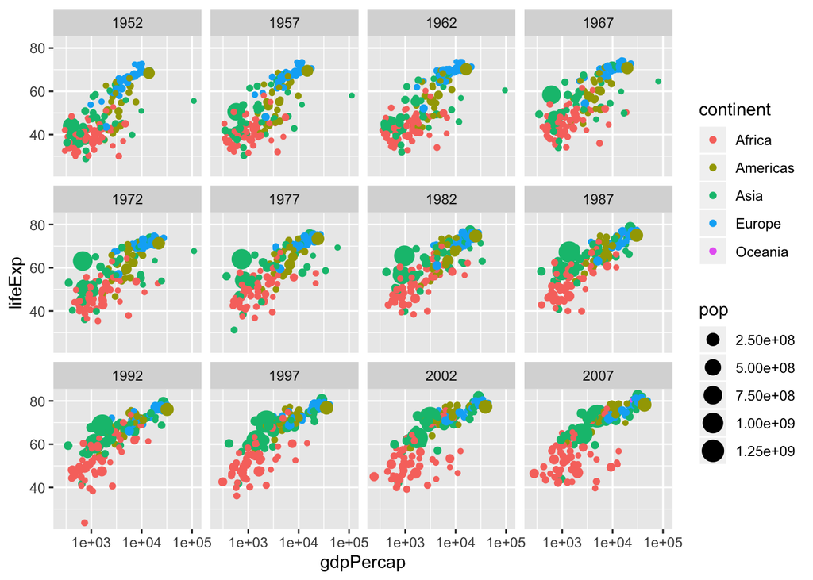

```r
  ggplot(gapminder, aes(x = gdpPercap, y = lifeExp, color = continent, size = pop)) + geom_point() + facet_wrap(~year) + scale_x_log10()
```

## ==== Grouping and summarizing ====

```r
  library(gapminder)
  library(dplyr)
```

```r
# Summarize to find the median life expectancy
  gapminder %>%
  summarise(medianLifeExp = median(lifeExp))
```

```
## # A tibble: 1 x 1
##   medianLifeExp
##           <dbl>
## 1          60.7
```

```r
library(gapminder)
library(dplyr)
```

```r
# Filter for 1957 then summarize the median life expectancy
gapminder %>%
 filter(year == 1957) %>%
  summarise(medianLifeExp = median(lifeExp))
```

```
## # A tibble: 1 x 1
##   medianLifeExp
##           <dbl>
## 1          48.4
```

```r
library(gapminder)
library(dplyr)
```

```r
# Filter for 1957 then summarize the median life expectancy and the maximum GDP per capita
gapminder %>%
  filter(year == 1957) %>%
    summarise(medianLifeExp = median(lifeExp), maxGdpPercap = max(gdpPercap))
```

```
## # A tibble: 1 x 2
##   medianLifeExp maxGdpPercap
##           <dbl>        <dbl>
## 1          48.4      113523.
```

```r
library(gapminder)
library(dplyr)

# Find median life expectancy and maximum GDP per capita in each year
gapminder %>%
  group_by(year) %>%
   summarise ( medianLifeExp = median(lifeExp), maxGdpPercap = max(gdpPercap))
```

```
## # A tibble: 12 x 3
##     year medianLifeExp maxGdpPercap
##    <int>         <dbl>        <dbl>
##  1  1952          45.1      108382.
##  2  1957          48.4      113523.
##  3  1962          50.9       95458.
##  4  1967          53.8       80895.
##  5  1972          56.5      109348.
##  6  1977          59.7       59265.
##  7  1982          62.4       33693.
##  8  1987          65.8       31541.
##  9  1992          67.7       34933.
## 10  1997          69.4       41283.
## 11  2002          70.8       44684.
## 12  2007          71.9       49357.
```

```r
library(gapminder)
library(dplyr)

# Find median life expectancy and maximum GDP per capita in each continent in 1957
gapminder %>%
  filter(year == 1957) %>%
    group_by(continent) %>%
      summarise (medianLifeExp = median(lifeExp), maxGdpPercap = max(gdpPercap))
```

```
## # A tibble: 5 x 3
##   continent medianLifeExp maxGdpPercap
##   <fct>             <dbl>        <dbl>
## 1 Africa             40.6        5487.
## 2 Americas           56.1       14847.
## 3 Asia               48.3      113523.
## 4 Europe             67.6       17909.
## 5 Oceania            70.3       12247.
```

```r
library(gapminder)
library(dplyr)

# Find median life expectancy and maximum GDP per capita in each continent/year combination
gapminder %>%
    group_by(continent,year) %>%
      summarise (medianLifeExp = median(lifeExp), maxGdpPercap = max(gdpPercap))
```

```
## # A tibble: 60 x 4
## # Groups:   continent [5]
##    continent  year medianLifeExp maxGdpPercap
##    <fct>     <int>         <dbl>        <dbl>
##  1 Africa     1952          38.8        4725.
##  2 Africa     1957          40.6        5487.
##  3 Africa     1962          42.6        6757.
##  4 Africa     1967          44.7       18773.
##  5 Africa     1972          47.0       21011.
##  6 Africa     1977          49.3       21951.
##  7 Africa     1982          50.8       17364.
##  8 Africa     1987          51.6       11864.
##  9 Africa     1992          52.4       13522.
## 10 Africa     1997          52.8       14723.
## # … with 50 more rows
```

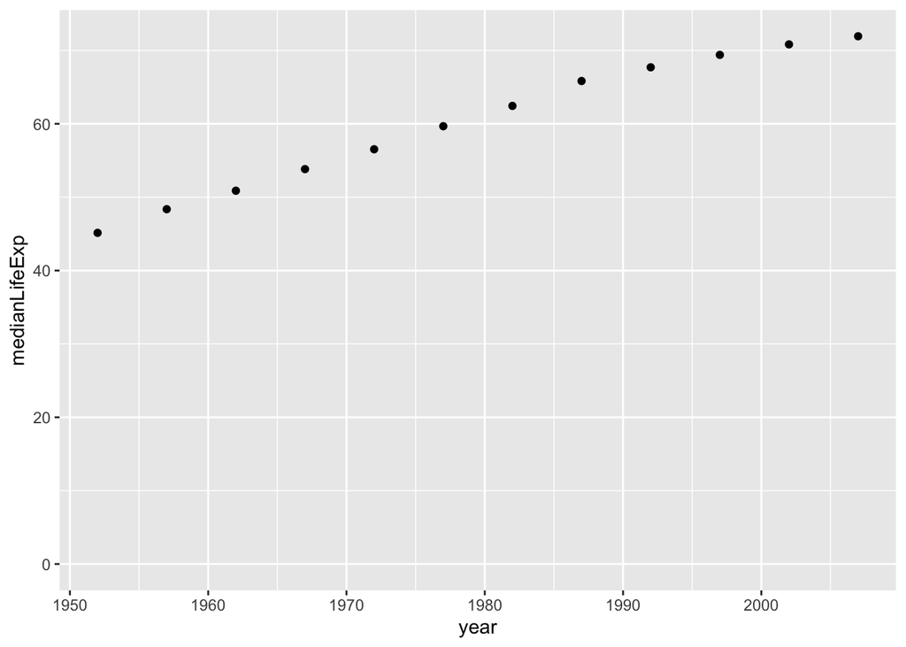

```r
library(gapminder)
library(dplyr)
library(ggplot2)

by_year <- gapminder %>%
  group_by(year) %>%
  summarize(medianLifeExp = median(lifeExp),
            maxGdpPercap = max(gdpPercap))

# Create a scatter plot showing the change in medianLifeExp over time
ggplot(by_year, aes(x = year, y = medianLifeExp)) + geom_point() + expand_limits(y = 0)
```

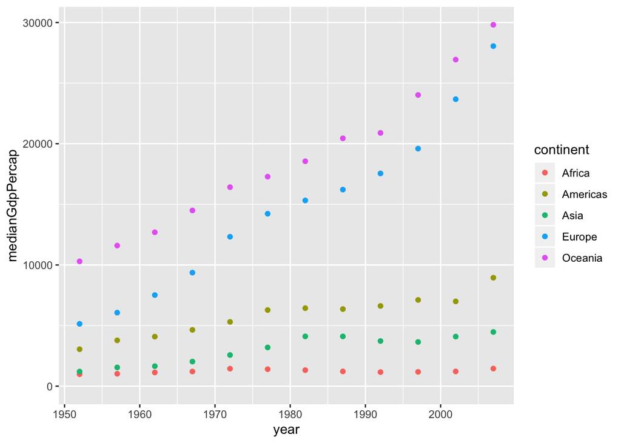

```r
library(gapminder)
library(dplyr)
library(ggplot2)

# Summarize medianGdpPercap within each continent within each year: by_year_continent
by_year_continent <- gapminder %>%
  group_by(continent,year) %>%
  summarize(medianGdpPercap = median(gdpPercap))

# Plot the change in medianGdpPercap in each continent over time
ggplot(by_year_continent, aes(x = year, y = medianGdpPercap, color = continent)) + geom_point() + expand_limits(y = 0)
```

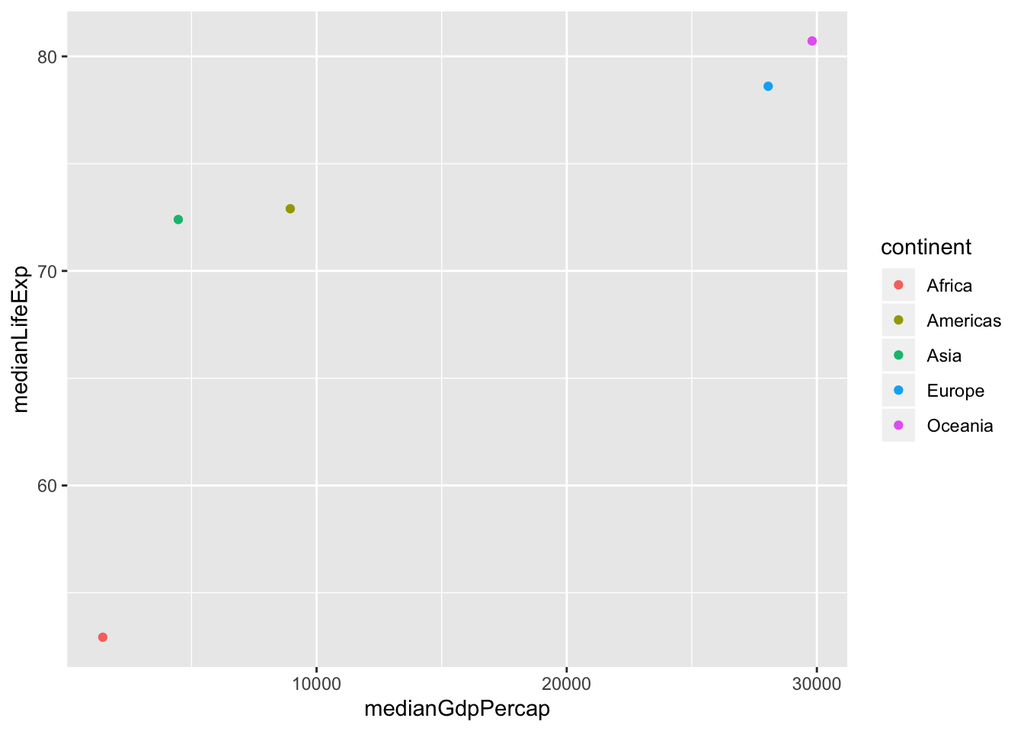

```r
library(gapminder)
library(dplyr)
library(ggplot2)

# Summarize the median GDP and median life expectancy per continent in 2007
by_continent_2007 <- gapminder %>%
  filter(year == 2007) %>%
    group_by(continent) %>%
      summarise(medianLifeExp = median(lifeExp), medianGdpPercap = median (gdpPercap))

# Use a scatter plot to compare the median GDP and median life expectancy
ggplot(by_continent_2007, aes(x = medianGdpPercap, y = medianLifeExp, color = continent)) + geom_point()
```

## ==== Types of visualizations ====

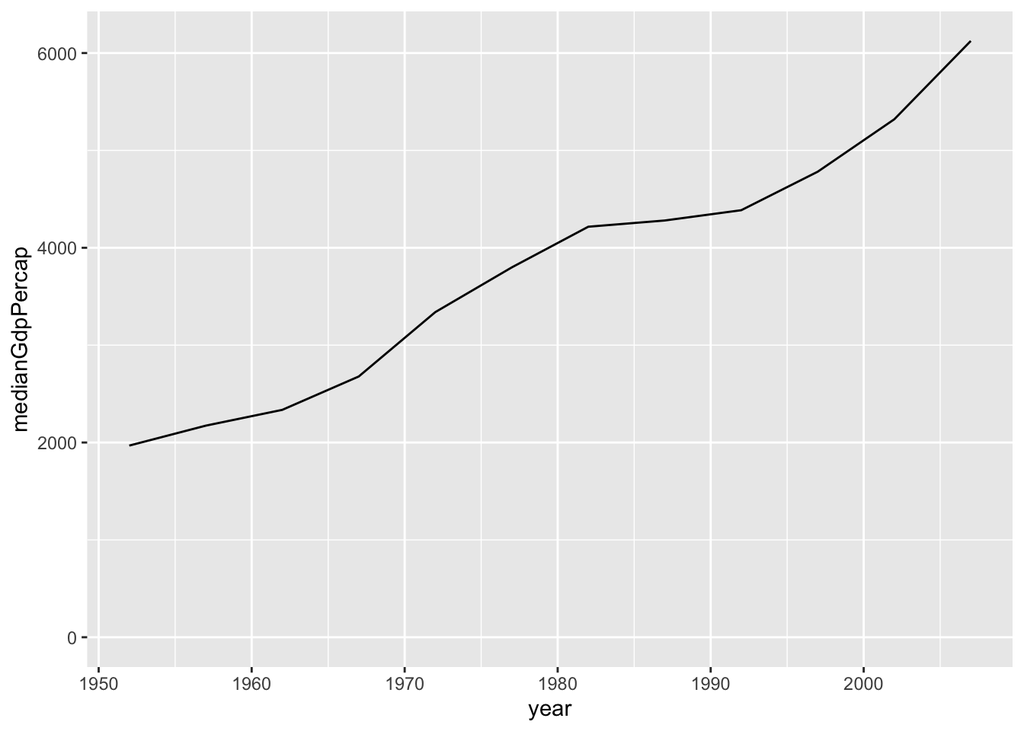

```r
library(gapminder)
library(dplyr)
library(ggplot2)

# Summarize the median gdpPercap by year, then save it as by_year
by_year <- gapminder %>%
  group_by(year) %>%
    summarise ( medianGdpPercap = median(gdpPercap))

# Create a line plot showing the change in medianGdpPercap over time
ggplot(by_year, aes(x = year, y = medianGdpPercap )) + geom_line() + expand_limits(y = 0)
```

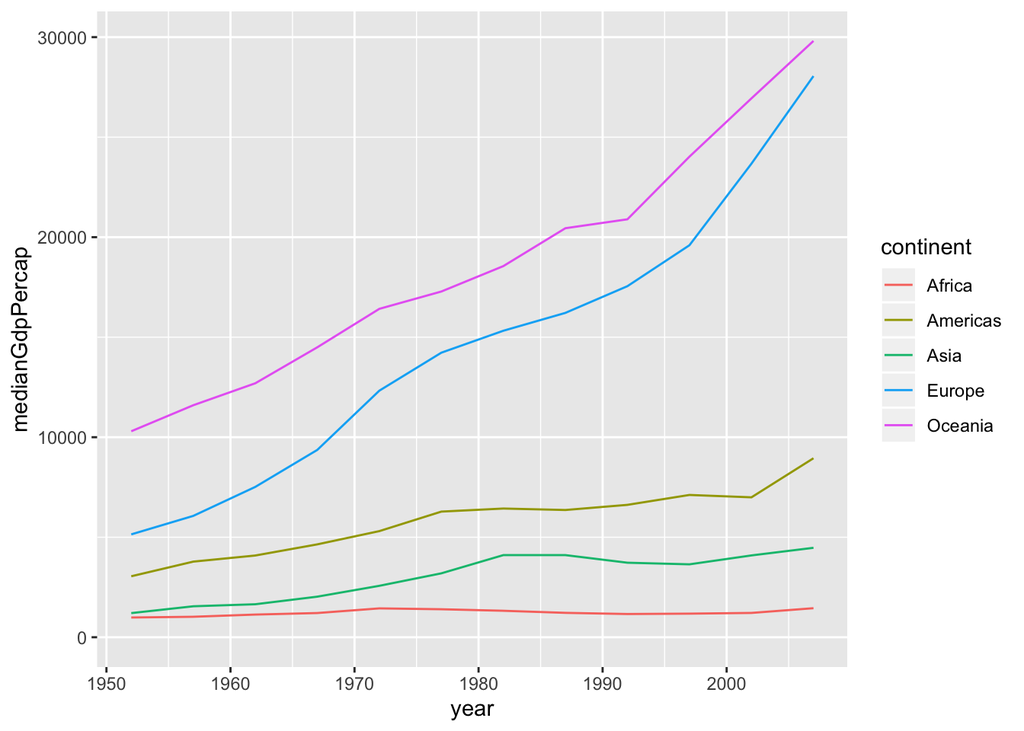

```r
library(gapminder)
library(dplyr)
library(ggplot2)

# Summarize the median gdpPercap by year & continent, save as by_year_continent
by_year_continent <- gapminder %>%
  group_by(year,continent) %>%
    summarise(medianGdpPercap = median(gdpPercap))

# Create a line plot showing the change in medianGdpPercap by continent over time
ggplot(by_year_continent, aes(x = year, y = medianGdpPercap, color = continent)) + geom_line() + expand_limits(y = 0)
```

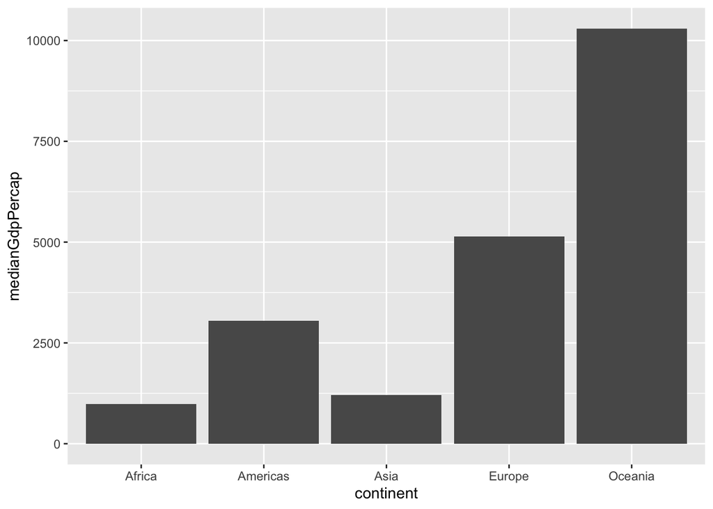

```r
library(gapminder)
library(dplyr)
library(ggplot2)

# Summarize the median gdpPercap by continent in 1952
by_continent <- gapminder %>%
  filter ( year == 1952) %>%
    group_by(continent) %>%
      summarise(medianGdpPercap = median(gdpPercap))

# Create a bar plot showing medianGdp by continent
ggplot(by_continent, aes(x= continent, medianGdpPercap)) + geom_col()
```

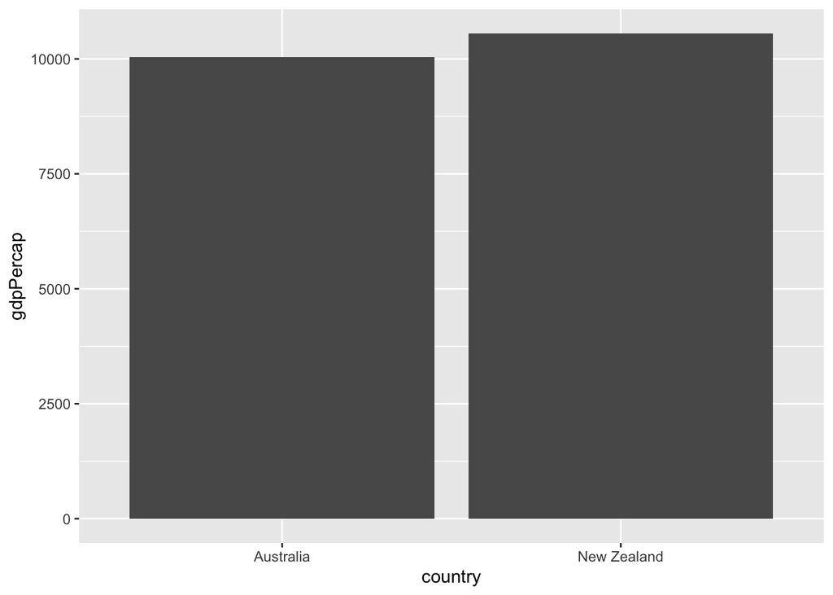

```r
library(gapminder)
library(dplyr)
library(ggplot2)

# Filter for observations in the Oceania continent in 1952
oceania_1952 <- gapminder %>%
  filter(year == 1952, continent == "Oceania")


# Create a bar plot of gdpPercap by country
ggplot(oceania_1952, aes(x = country, y = gdpPercap)) + geom_col()
```

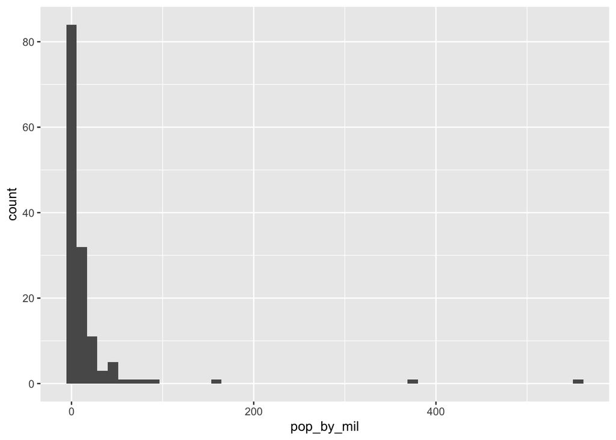

```r
library(gapminder)
library(dplyr)
library(ggplot2)

gapminder_1952 <- gapminder %>%
  filter(year == 1952) %>%
  mutate(pop_by_mil = pop / 1000000)

# Create a histogram of population (pop_by_mil)
ggplot(gapminder_1952, aes(x = pop_by_mil)) + geom_histogram(bins = 50)
```

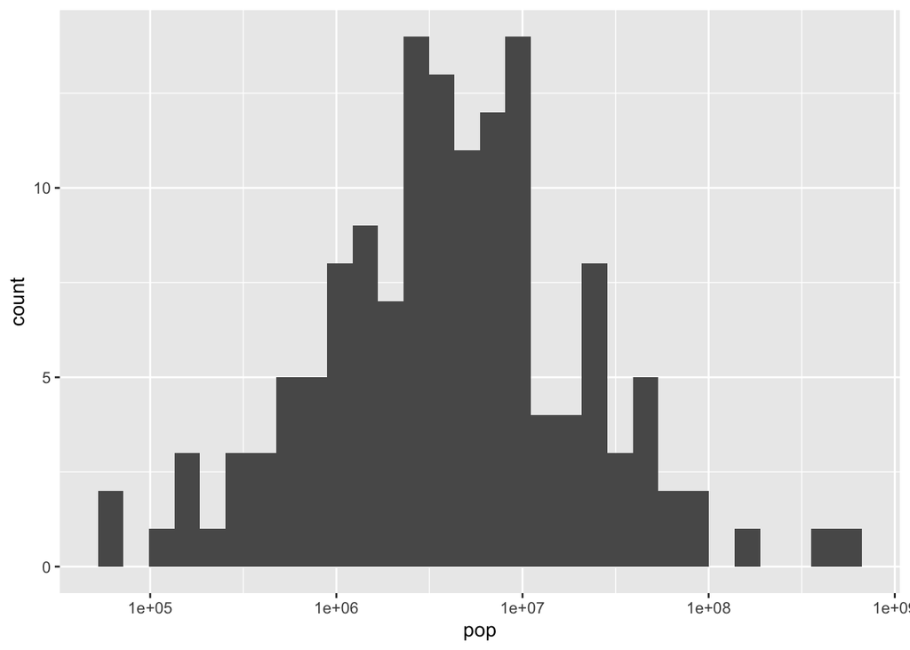

```r
library(gapminder)
library(dplyr)
library(ggplot2)

gapminder_1952 <- gapminder %>%
  filter(year == 1952)

# Create a histogram of population (pop), with x on a log scale
ggplot(gapminder_1952,aes(x = pop)) + geom_histogram() + scale_x_log10()
```

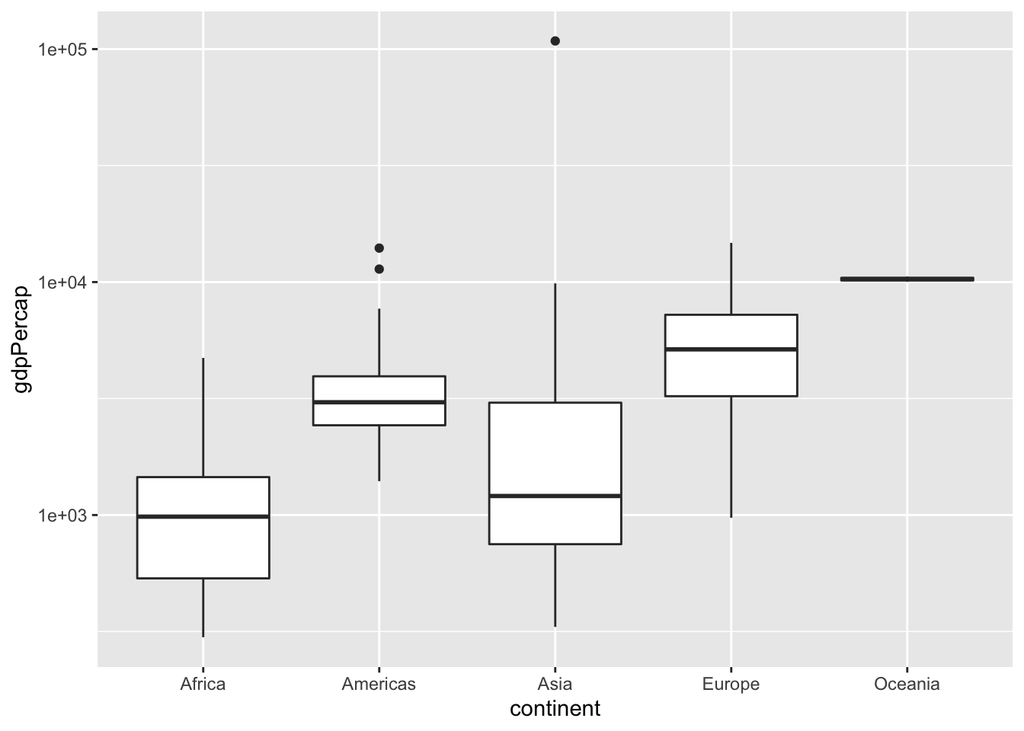

```r
library(gapminder)
library(dplyr)
library(ggplot2)

gapminder_1952 <- gapminder %>%
  filter(year == 1952)

# Create a boxplot comparing gdpPercap among continents
ggplot(gapminder_1952, aes(x = continent, y = gdpPercap)) + geom_boxplot() + scale_y_log10()
```

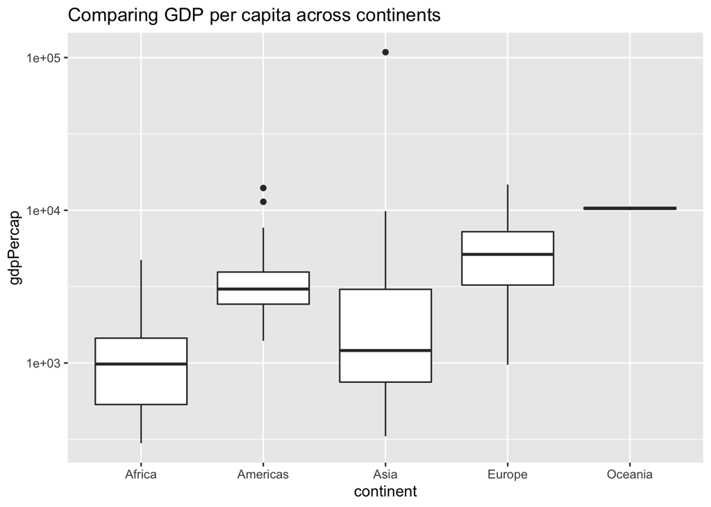

```r
library(gapminder)
library(dplyr)
library(ggplot2)

gapminder_1952 <- gapminder %>%
  filter(year == 1952)

# Add a title to this graph: "Comparing GDP per capita across continents"
p <- ggplot(gapminder_1952, aes(x = continent, y = gdpPercap)) +
  geom_boxplot() +
  scale_y_log10()

p + ggtitle("Comparing GDP per capita across continents")
```

## ==== Importing Data in R (Part 1) ====

```r
# Import swimming_pools.csv: pools
pools <- read.csv("data_dcamp/swimming_pools.csv",header = TRUE)

# Print the structure of pools
str(pools)
```

```
## 'data.frame':    20 obs. of  4 variables:
##  $ Name     : Factor w/ 20 levels "Acacia Ridge Leisure Centre",..: 1 2 3 4 5 6 19 7 8 9 ...
##  $ Address  : Factor w/ 20 levels "1 Fairlead Crescent, Manly",..: 5 20 18 10 9 11 6 15 12 17 ...
##  $ Latitude : num  -27.6 -27.6 -27.6 -27.5 -27.4 ...
##  $ Longitude: num  153 153 153 153 153 ...
```

```r
# Import swimming_pools.csv correctly: pools
pools <- read.csv("data_dcamp/swimming_pools.csv", stringsAsFactors = FALSE)

# Check the structure of pools
str(pools)
```

```
## 'data.frame':    20 obs. of  4 variables:
##  $ Name     : chr  "Acacia Ridge Leisure Centre" "Bellbowrie Pool" "Carole Park" "Centenary Pool (inner City)" ...
##  $ Address  : chr  "1391 Beaudesert Road, Acacia Ridge" "Sugarwood Street, Bellbowrie" "Cnr Boundary Road and Waterford Road Wacol" "400 Gregory Terrace, Spring Hill" ...
##  $ Latitude : num  -27.6 -27.6 -27.6 -27.5 -27.4 ...
##  $ Longitude: num  153 153 153 153 153 ...
```

```r
# Import hotdogs.txt: hotdogs
hotdogs <- read.delim("data_dcamp/hotdogs.txt" , header = FALSE)

# Summarize hotdogs
summary(hotdogs)
```

```
##        V1           V2              V3
##  Beef   :20   Min.   : 86.0   Min.   :144.0
##  Meat   :17   1st Qu.:132.0   1st Qu.:362.5
##  Poultry:17   Median :145.0   Median :405.0
##               Mean   :145.4   Mean   :424.8
##               3rd Qu.:172.8   3rd Qu.:503.5
##               Max.   :195.0   Max.   :645.0
```

```r
# Path to the hotdogs.txt file: path
path <- file.path("data_dcamp/", "hotdogs.txt")

# Import the hotdogs.txt file: hotdogs
hotdogs <- read.table(path,
                      sep = "\t",
                      col.names = c("type", "calories", "sodium"), header = FALSE)

# Call head() on hotdogs
head(hotdogs)
```

```
##   type calories sodium
## 1 Beef      186    495
## 2 Beef      181    477
## 3 Beef      176    425
## 4 Beef      149    322
## 5 Beef      184    482
## 6 Beef      190    587
```

```r
# Finish the read.delim() call
hotdogs <- read.delim("data_dcamp/hotdogs.txt", header = FALSE, col.names = c("type", "calories", "sodium"))

# Select the hot dog with the least calories: lily
lily <- hotdogs[which.min(hotdogs$calories), ]

# Select the observation with the most sodium: tom
tom <- hotdogs[which.max(hotdogs$sodium), ]

# Print lily and tom
lily
```

```
##       type calories sodium
## 50 Poultry       86    358
```

```r
tom
```

```
##    type calories sodium
## 15 Beef      190    645
```

```r
# Previous call to import hotdogs.txt
hotdogs <- read.delim("data_dcamp/hotdogs.txt", header = FALSE, col.names = c("type", "calories", "sodium"))

# Display structure of hotdogs
str(hotdogs)
```

```
## 'data.frame':    54 obs. of  3 variables:
##  $ type    : Factor w/ 3 levels "Beef","Meat",..: 1 1 1 1 1 1 1 1 1 1 ...
##  $ calories: int  186 181 176 149 184 190 158 139 175 148 ...
##  $ sodium  : int  495 477 425 322 482 587 370 322 479 375 ...
```

```r
# Edit the colClasses argument to import the data correctly: hotdogs2
hotdogs2 <- read.delim("data_dcamp/hotdogs.txt", header = FALSE,
                       col.names = c("type", "calories", "sodium"),
                       colClasses = c("factor","NULL","numeric"))


# Display structure of hotdogs2
str(hotdogs2)
```

```
## 'data.frame':    54 obs. of  2 variables:
##  $ type  : Factor w/ 3 levels "Beef","Meat",..: 1 1 1 1 1 1 1 1 1 1 ...
##  $ sodium: num  495 477 425 322 482 587 370 322 479 375 ...
```

```r
# readr is already loaded
library(readr)
# Column names
properties <- c("area", "temp", "size", "storage", "method",
                "texture", "flavor", "moistness")

# Import potatoes.txt: potatoes
potatoes <- read_tsv("data_dcamp/potatoes.txt", col_names = properties)
# Call head() on potatoes
head(potatoes)
```

```
## # A tibble: 6 x 8
##    area  temp  size storage method texture flavor moistness
##   <dbl> <dbl> <dbl>   <dbl>  <dbl>   <dbl>  <dbl>     <dbl>
## 1     1     1     1       1      1     2.9    3.2       3
## 2     1     1     1       1      2     2.3    2.5       2.6
## 3     1     1     1       1      3     2.5    2.8       2.8
## 4     1     1     1       1      4     2.1    2.9       2.4
## 5     1     1     1       1      5     1.9    2.8       2.2
## 6     1     1     1       2      1     1.8    3         1.7
```

```r
# readr is already loaded

# Column names
properties <- c("area", "temp", "size", "storage", "method",
                "texture", "flavor", "moistness")

# Import potatoes.txt using read_delim(): potatoes
potatoes <- read_delim("data_dcamp/potatoes.txt", delim = "\t", col_names = properties)
# Print out potatoes
potatoes
```

```
## # A tibble: 160 x 8
##     area  temp  size storage method texture flavor moistness
##    <dbl> <dbl> <dbl>   <dbl>  <dbl>   <dbl>  <dbl>     <dbl>
##  1     1     1     1       1      1     2.9    3.2       3
##  2     1     1     1       1      2     2.3    2.5       2.6
##  3     1     1     1       1      3     2.5    2.8       2.8
##  4     1     1     1       1      4     2.1    2.9       2.4
##  5     1     1     1       1      5     1.9    2.8       2.2
##  6     1     1     1       2      1     1.8    3         1.7
##  7     1     1     1       2      2     2.6    3.1       2.4
##  8     1     1     1       2      3     3      3         2.9
##  9     1     1     1       2      4     2.2    3.2       2.5
## 10     1     1     1       2      5     2      2.8       1.9
## # … with 150 more rows
```

```r
# readr is already loaded

# Column names
properties <- c("area", "temp", "size", "storage", "method",
                "texture", "flavor", "moistness")

# Import 5 observations from potatoes.txt: potatoes_fragment
potatoes_fragment <- read_tsv("data_dcamp/potatoes.txt", skip = 6, n_max = 5, col_names = properties)
# readr is already loaded

# Column names
properties <- c("area", "temp", "size", "storage", "method",
                "texture", "flavor", "moistness")

# Import all data, but force all columns to be character: potatoes_char
potatoes_char <- read_tsv("data_dcamp/potatoes.txt", col_types = "cccccccc", col_names = properties)

# Print out structure of potatoes_char
str(potatoes_char)
```

```
## Classes 'spec_tbl_df', 'tbl_df', 'tbl' and 'data.frame': 160 obs. of  8 variables:
##  $ area     : chr  "1" "1" "1" "1" ...
##  $ temp     : chr  "1" "1" "1" "1" ...
##  $ size     : chr  "1" "1" "1" "1" ...
##  $ storage  : chr  "1" "1" "1" "1" ...
##  $ method   : chr  "1" "2" "3" "4" ...
##  $ texture  : chr  "2.9" "2.3" "2.5" "2.1" ...
##  $ flavor   : chr  "3.2" "2.5" "2.8" "2.9" ...
##  $ moistness: chr  "3.0" "2.6" "2.8" "2.4" ...
##  - attr(*, "spec")=
##   .. cols(
##   ..   area = col_character(),
##   ..   temp = col_character(),
##   ..   size = col_character(),
##   ..   storage = col_character(),
##   ..   method = col_character(),
##   ..   texture = col_character(),
##   ..   flavor = col_character(),
##   ..   moistness = col_character()
##   .. )
```

```r
# readr is already loaded

# Import without col_types
hotdogs <- read_tsv("data_dcamp/hotdogs.txt", col_names = c("type", "calories", "sodium"))
# Display the summary of hotdogs
summary(hotdogs)
```

```
##      type              calories         sodium
##  Length:54          Min.   : 86.0   Min.   :144.0
##  Class :character   1st Qu.:132.0   1st Qu.:362.5
##  Mode  :character   Median :145.0   Median :405.0
##                     Mean   :145.4   Mean   :424.8
##                     3rd Qu.:172.8   3rd Qu.:503.5
##                     Max.   :195.0   Max.   :645.0
```

```r
# The collectors you will need to import the data
fac <- col_factor(levels = c("Beef", "Meat", "Poultry"))
int <- col_integer()

# Edit the col_types argument to import the data correctly: hotdogs_factor
hotdogs_factor <- read_tsv("data_dcamp/hotdogs.txt",
                           col_names = c("type", "calories", "sodium"),
                           col_types = list(fac,int,int))

# Display the summary of hotdogs_factor
summary(hotdogs_factor)
```

```
##       type       calories         sodium
##  Beef   :20   Min.   : 86.0   Min.   :144.0
##  Meat   :17   1st Qu.:132.0   1st Qu.:362.5
##  Poultry:17   Median :145.0   Median :405.0
##               Mean   :145.4   Mean   :424.8
##               3rd Qu.:172.8   3rd Qu.:503.5
##               Max.   :195.0   Max.   :645.0
```

```r
# load the data.table package using library()
library(data.table)
# Import potatoes.csv with fread(): potatoes
potatoes <- fread("data_dcamp/potatoes.csv")

# Print out potatoes
potatoes
```

```
##      area temp size storage method texture flavor moistness
##   1:    1    1    1       1      1     2.9    3.2       3.0
##   2:    1    1    1       1      2     2.3    2.5       2.6
##   3:    1    1    1       1      3     2.5    2.8       2.8
##   4:    1    1    1       1      4     2.1    2.9       2.4
##   5:    1    1    1       1      5     1.9    2.8       2.2
##  ---
## 156:    2    2    2       4      1     2.7    3.3       2.6
## 157:    2    2    2       4      2     2.6    2.8       2.3
## 158:    2    2    2       4      3     2.5    3.1       2.6
## 159:    2    2    2       4      4     3.4    3.3       3.0
## 160:    2    2    2       4      5     2.5    2.8       2.3
```

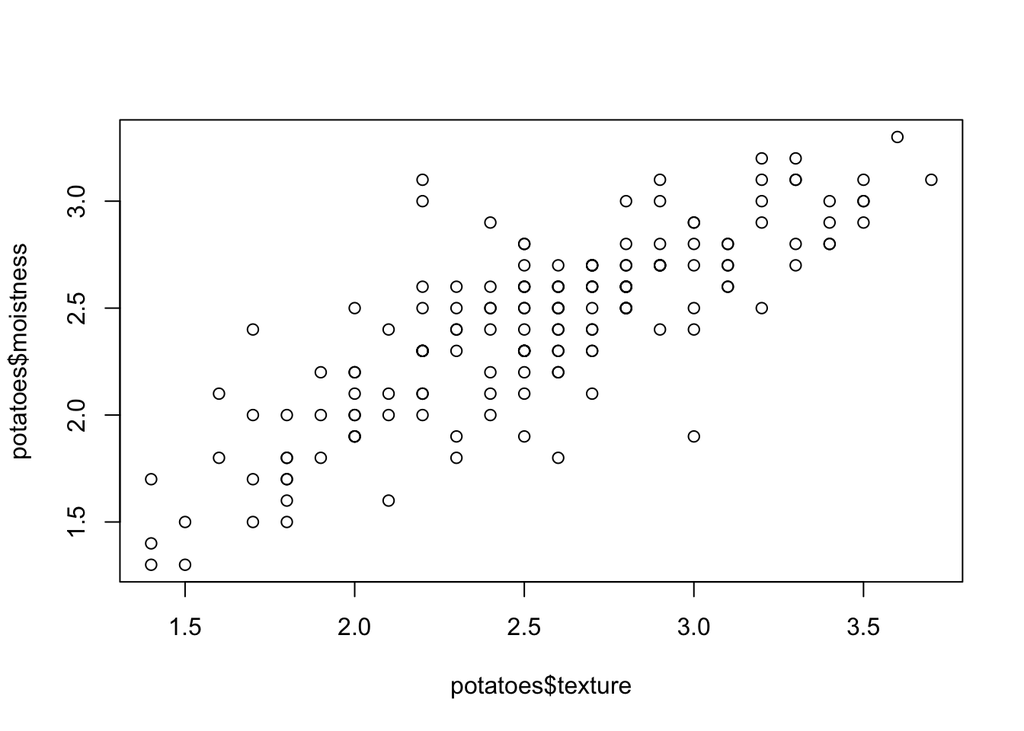

```r
# fread is already loaded

# Import columns 6 and 8 of potatoes.csv: potatoes
potatoes <- fread("data_dcamp/potatoes.csv", select = c(6,8) )

# Plot texture (x) and moistness (y) of potatoes
plot(potatoes$texture, potatoes$moistness)
```

```r
# Load the readxl package
library(readxl)

# Print the names of all worksheets
excel_sheets("data_dcamp/urbanpop.xlsx")
```

```
## [1] "1960-1966" "1967-1974" "1975-2011"
```

```r
# The readxl package is already loaded

# Read the sheets, one by one
pop_1 <- read_excel("data_dcamp/urbanpop.xlsx", sheet = 1)
pop_2 <- read_excel("data_dcamp/urbanpop.xlsx", sheet = 2)
pop_3 <- read_excel("data_dcamp/urbanpop.xlsx", sheet = 3)

# Put pop_1, pop_2 and pop_3 in a list: pop_list
pop_list <- list(pop_1, pop_2, pop_3)

# Display the structure of pop_list
str(pop_list)
```

```
## List of 3
##  $ :Classes 'tbl_df', 'tbl' and 'data.frame':    209 obs. of  8 variables:
##   ..$ country: chr [1:209] "Afghanistan" "Albania" "Algeria" "American Samoa" ...
##   ..$ 1960   : num [1:209] 769308 494443 3293999 NA NA ...
##   ..$ 1961   : num [1:209] 814923 511803 3515148 13660 8724 ...
##   ..$ 1962   : num [1:209] 858522 529439 3739963 14166 9700 ...
##   ..$ 1963   : num [1:209] 903914 547377 3973289 14759 10748 ...
##   ..$ 1964   : num [1:209] 951226 565572 4220987 15396 11866 ...
##   ..$ 1965   : num [1:209] 1000582 583983 4488176 16045 13053 ...
##   ..$ 1966   : num [1:209] 1058743 602512 4649105 16693 14217 ...
##  $ :Classes 'tbl_df', 'tbl' and 'data.frame':    209 obs. of  9 variables:
##   ..$ country: chr [1:209] "Afghanistan" "Albania" "Algeria" "American Samoa" ...
##   ..$ 1967   : num [1:209] 1119067 621180 4826104 17349 15440 ...
##   ..$ 1968   : num [1:209] 1182159 639964 5017299 17996 16727 ...
##   ..$ 1969   : num [1:209] 1248901 658853 5219332 18619 18088 ...
##   ..$ 1970   : num [1:209] 1319849 677839 5429743 19206 19529 ...
##   ..$ 1971   : num [1:209] 1409001 698932 5619042 19752 20929 ...
##   ..$ 1972   : num [1:209] 1502402 720207 5815734 20263 22406 ...
##   ..$ 1973   : num [1:209] 1598835 741681 6020647 20742 23937 ...
##   ..$ 1974   : num [1:209] 1696445 763385 6235114 21194 25482 ...
##  $ :Classes 'tbl_df', 'tbl' and 'data.frame':    209 obs. of  38 variables:
##   ..$ country: chr [1:209] "Afghanistan" "Albania" "Algeria" "American Samoa" ...
##   ..$ 1975   : num [1:209] 1793266 785350 6460138 21632 27019 ...
##   ..$ 1976   : num [1:209] 1905033 807990 6774099 22047 28366 ...
##   ..$ 1977   : num [1:209] 2021308 830959 7102902 22452 29677 ...
##   ..$ 1978   : num [1:209] 2142248 854262 7447728 22899 31037 ...
##   ..$ 1979   : num [1:209] 2268015 877898 7810073 23457 32572 ...
##   ..$ 1980   : num [1:209] 2398775 901884 8190772 24177 34366 ...
##   ..$ 1981   : num [1:209] 2493265 927224 8637724 25173 36356 ...
##   ..$ 1982   : num [1:209] 2590846 952447 9105820 26342 38618 ...
##   ..$ 1983   : num [1:209] 2691612 978476 9591900 27655 40983 ...
##   ..$ 1984   : num [1:209] 2795656 1006613 10091289 29062 43207 ...
##   ..$ 1985   : num [1:209] 2903078 1037541 10600112 30524 45119 ...
##   ..$ 1986   : num [1:209] 3006983 1072365 11101757 32014 46254 ...
##   ..$ 1987   : num [1:209] 3113957 1109954 11609104 33548 47019 ...
##   ..$ 1988   : num [1:209] 3224082 1146633 12122941 35095 47669 ...
##   ..$ 1989   : num [1:209] 3337444 1177286 12645263 36618 48577 ...
##   ..$ 1990   : num [1:209] 3454129 1198293 13177079 38088 49982 ...
##   ..$ 1991   : num [1:209] 3617842 1215445 13708813 39600 51972 ...
##   ..$ 1992   : num [1:209] 3788685 1222544 14248297 41049 54469 ...
##   ..$ 1993   : num [1:209] 3966956 1222812 14789176 42443 57079 ...
##   ..$ 1994   : num [1:209] 4152960 1221364 15322651 43798 59243 ...
##   ..$ 1995   : num [1:209] 4347018 1222234 15842442 45129 60598 ...
##   ..$ 1996   : num [1:209] 4531285 1228760 16395553 46343 60927 ...
##   ..$ 1997   : num [1:209] 4722603 1238090 16935451 47527 60462 ...
##   ..$ 1998   : num [1:209] 4921227 1250366 17469200 48705 59685 ...
##   ..$ 1999   : num [1:209] 5127421 1265195 18007937 49906 59281 ...
##   ..$ 2000   : num [1:209] 5341456 1282223 18560597 51151 59719 ...
##   ..$ 2001   : num [1:209] 5564492 1315690 19198872 52341 61062 ...
##   ..$ 2002   : num [1:209] 5795940 1352278 19854835 53583 63212 ...
##   ..$ 2003   : num [1:209] 6036100 1391143 20529356 54864 65802 ...
##   ..$ 2004   : num [1:209] 6285281 1430918 21222198 56166 68301 ...
##   ..$ 2005   : num [1:209] 6543804 1470488 21932978 57474 70329 ...
##   ..$ 2006   : num [1:209] 6812538 1512255 22625052 58679 71726 ...
##   ..$ 2007   : num [1:209] 7091245 1553491 23335543 59894 72684 ...
##   ..$ 2008   : num [1:209] 7380272 1594351 24061749 61118 73335 ...
##   ..$ 2009   : num [1:209] 7679982 1635262 24799591 62357 73897 ...
##   ..$ 2010   : num [1:209] 7990746 1676545 25545622 63616 74525 ...
##   ..$ 2011   : num [1:209] 8316976 1716842 26216968 64817 75207 ...
```

```r
# The readxl package is already loaded

# Read all Excel sheets with lapply(): pop_list
pop_list <- lapply(excel_sheets("data_dcamp/urbanpop.xlsx"),read_excel, path = "data_dcamp/urbanpop.xlsx")

# Display the structure of pop_list
str(pop_list)
```

```
## List of 3
##  $ :Classes 'tbl_df', 'tbl' and 'data.frame':    209 obs. of  8 variables:
##   ..$ country: chr [1:209] "Afghanistan" "Albania" "Algeria" "American Samoa" ...
##   ..$ 1960   : num [1:209] 769308 494443 3293999 NA NA ...
##   ..$ 1961   : num [1:209] 814923 511803 3515148 13660 8724 ...
##   ..$ 1962   : num [1:209] 858522 529439 3739963 14166 9700 ...
##   ..$ 1963   : num [1:209] 903914 547377 3973289 14759 10748 ...
##   ..$ 1964   : num [1:209] 951226 565572 4220987 15396 11866 ...
##   ..$ 1965   : num [1:209] 1000582 583983 4488176 16045 13053 ...
##   ..$ 1966   : num [1:209] 1058743 602512 4649105 16693 14217 ...
##  $ :Classes 'tbl_df', 'tbl' and 'data.frame':    209 obs. of  9 variables:
##   ..$ country: chr [1:209] "Afghanistan" "Albania" "Algeria" "American Samoa" ...
##   ..$ 1967   : num [1:209] 1119067 621180 4826104 17349 15440 ...
##   ..$ 1968   : num [1:209] 1182159 639964 5017299 17996 16727 ...
##   ..$ 1969   : num [1:209] 1248901 658853 5219332 18619 18088 ...
##   ..$ 1970   : num [1:209] 1319849 677839 5429743 19206 19529 ...
##   ..$ 1971   : num [1:209] 1409001 698932 5619042 19752 20929 ...
##   ..$ 1972   : num [1:209] 1502402 720207 5815734 20263 22406 ...
##   ..$ 1973   : num [1:209] 1598835 741681 6020647 20742 23937 ...
##   ..$ 1974   : num [1:209] 1696445 763385 6235114 21194 25482 ...
##  $ :Classes 'tbl_df', 'tbl' and 'data.frame':    209 obs. of  38 variables:
##   ..$ country: chr [1:209] "Afghanistan" "Albania" "Algeria" "American Samoa" ...
##   ..$ 1975   : num [1:209] 1793266 785350 6460138 21632 27019 ...
##   ..$ 1976   : num [1:209] 1905033 807990 6774099 22047 28366 ...
##   ..$ 1977   : num [1:209] 2021308 830959 7102902 22452 29677 ...
##   ..$ 1978   : num [1:209] 2142248 854262 7447728 22899 31037 ...
##   ..$ 1979   : num [1:209] 2268015 877898 7810073 23457 32572 ...
##   ..$ 1980   : num [1:209] 2398775 901884 8190772 24177 34366 ...
##   ..$ 1981   : num [1:209] 2493265 927224 8637724 25173 36356 ...
##   ..$ 1982   : num [1:209] 2590846 952447 9105820 26342 38618 ...
##   ..$ 1983   : num [1:209] 2691612 978476 9591900 27655 40983 ...
##   ..$ 1984   : num [1:209] 2795656 1006613 10091289 29062 43207 ...
##   ..$ 1985   : num [1:209] 2903078 1037541 10600112 30524 45119 ...
##   ..$ 1986   : num [1:209] 3006983 1072365 11101757 32014 46254 ...
##   ..$ 1987   : num [1:209] 3113957 1109954 11609104 33548 47019 ...
##   ..$ 1988   : num [1:209] 3224082 1146633 12122941 35095 47669 ...
##   ..$ 1989   : num [1:209] 3337444 1177286 12645263 36618 48577 ...
##   ..$ 1990   : num [1:209] 3454129 1198293 13177079 38088 49982 ...
##   ..$ 1991   : num [1:209] 3617842 1215445 13708813 39600 51972 ...
##   ..$ 1992   : num [1:209] 3788685 1222544 14248297 41049 54469 ...
##   ..$ 1993   : num [1:209] 3966956 1222812 14789176 42443 57079 ...
##   ..$ 1994   : num [1:209] 4152960 1221364 15322651 43798 59243 ...
##   ..$ 1995   : num [1:209] 4347018 1222234 15842442 45129 60598 ...
##   ..$ 1996   : num [1:209] 4531285 1228760 16395553 46343 60927 ...
##   ..$ 1997   : num [1:209] 4722603 1238090 16935451 47527 60462 ...
##   ..$ 1998   : num [1:209] 4921227 1250366 17469200 48705 59685 ...
##   ..$ 1999   : num [1:209] 5127421 1265195 18007937 49906 59281 ...
##   ..$ 2000   : num [1:209] 5341456 1282223 18560597 51151 59719 ...
##   ..$ 2001   : num [1:209] 5564492 1315690 19198872 52341 61062 ...
##   ..$ 2002   : num [1:209] 5795940 1352278 19854835 53583 63212 ...
##   ..$ 2003   : num [1:209] 6036100 1391143 20529356 54864 65802 ...
##   ..$ 2004   : num [1:209] 6285281 1430918 21222198 56166 68301 ...
##   ..$ 2005   : num [1:209] 6543804 1470488 21932978 57474 70329 ...
##   ..$ 2006   : num [1:209] 6812538 1512255 22625052 58679 71726 ...
##   ..$ 2007   : num [1:209] 7091245 1553491 23335543 59894 72684 ...
##   ..$ 2008   : num [1:209] 7380272 1594351 24061749 61118 73335 ...
##   ..$ 2009   : num [1:209] 7679982 1635262 24799591 62357 73897 ...
##   ..$ 2010   : num [1:209] 7990746 1676545 25545622 63616 74525 ...
##   ..$ 2011   : num [1:209] 8316976 1716842 26216968 64817 75207 ...
```

```r
# The readxl package is already loaded

# Import the second sheet of urbanpop.xlsx, skipping the first 21 rows: urbanpop_sel
urbanpop_sel <- read_excel("data_dcamp/urbanpop.xlsx", sheet = 2, col_names = FALSE, skip = 21)
```

```
## * `` -> ...1
## * `` -> ...2
## * `` -> ...3
## * `` -> ...4
## * `` -> ...5
## * … and 4 more problems
```

```r
# Print out the first observation from urbanpop_sel
head(urbanpop_sel, n = 1)
```

```
## # A tibble: 1 x 9
##   ...1     ...2    ...3    ...4    ...5    ...6    ...7    ...8    ...9
##   <chr>   <dbl>   <dbl>   <dbl>   <dbl>   <dbl>   <dbl>   <dbl>   <dbl>
## 1 Benin 382022. 411859. 443013. 475611. 515820. 557938. 602093. 648410.
```

```r
# Load the gdata package
library(gdata)
# Import the second sheet of urbanpop.xls: urban_pop
urban_pop <- read.xls("data_dcamp/urbanpop.xls", sheet = 2)

# Print the first 11 observations using head()
head(urban_pop, n=11)
```

```
##                country       X1967       X1968       X1969       X1970
## 1          Afghanistan  1119067.20  1182159.06  1248900.79  1319848.78
## 2              Albania   621179.85   639964.46   658853.12   677839.12
## 3              Algeria  4826104.22  5017298.60  5219331.87  5429743.08
## 4       American Samoa    17348.66    17995.51    18618.68    19206.39
## 5              Andorra    15439.62    16726.99    18088.32    19528.96
## 6               Angola   757496.32   798459.26   841261.96   886401.63
## 7  Antigua and Barbuda    22086.25    22149.39    22182.92    22180.87
## 8            Argentina 17753280.98 18124103.64 18510462.30 18918072.79
## 9              Armenia  1337032.09  1392892.13  1449641.49  1507619.77
## 10               Aruba    29414.72    29576.09    29737.87    29901.57
## 11           Australia  9934404.03 10153969.77 10412390.67 10664093.55
##          X1971       X1972       X1973       X1974
## 1   1409001.09  1502401.79  1598835.45  1696444.83
## 2    698932.25   720206.57   741681.04   763385.45
## 3   5619041.53  5815734.49  6020647.35  6235114.38
## 4     19752.02    20262.67    20741.97    21194.38
## 5     20928.73    22405.84    23937.05    25481.98
## 6    955010.09  1027397.35  1103829.78  1184486.23
## 7     22560.87    22907.76    23221.29    23502.92
## 8  19329718.16 19763078.00 20211424.85 20664728.90
## 9   1564367.60  1622103.53  1680497.75  1739063.02
## 10    30081.36    30279.76    30467.42    30602.87
## 11 11047706.39 11269945.50 11461120.68 11772934.25
```

```r
# The gdata package is alreaded loaded

# Column names for urban_pop
columns <- c("country", paste0("year_", 1967:1974))

# Finish the read.xls call
urban_pop <- read.xls("data_dcamp/urbanpop.xls", sheet = 2,
                      skip = 50, header = FALSE, stringsAsFactors = FALSE,
                      col.names = columns)

# Print first 10 observation of urban_pop
head(urban_pop, n=10)
```

```
##               country   year_1967   year_1968   year_1969   year_1970
## 1              Cyprus   231929.74   237831.38   243983.34   250164.52
## 2      Czech Republic  6204409.91  6266304.50  6326368.97  6348794.89
## 3             Denmark  3777552.62  3826785.08  3874313.99  3930042.97
## 4            Djibouti    77788.04    84694.35    92045.77    99845.22
## 5            Dominica    27550.36    29527.32    31475.62    33328.25
## 6  Dominican Republic  1535485.43  1625455.76  1718315.40  1814060.00
## 7             Ecuador  2059355.12  2151395.14  2246890.79  2345864.41
## 8               Egypt 13798171.00 14248342.19 14703858.22 15162858.52
## 9         El Salvador  1345528.98  1387218.33  1429378.98  1472181.26
## 10  Equatorial Guinea    75364.50    77295.03    78445.74    78411.07
##      year_1971   year_1972   year_1973   year_1974
## 1    261213.21   272407.99   283774.90   295379.83
## 2   6437055.17  6572632.32  6718465.53  6873458.18
## 3   3981360.12  4028247.92  4076867.28  4120201.43
## 4    107799.69   116098.23   125391.58   136606.25
## 5     34761.52    36049.99    37260.05    38501.47
## 6   1915590.38  2020157.01  2127714.45  2238203.87
## 7   2453817.78  2565644.81  2681525.25  2801692.62
## 8  15603661.36 16047814.69 16498633.27 16960827.93
## 9   1527985.34  1584758.18  1642098.95  1699470.87
## 10    77055.29    74596.06    71438.96    68179.26
```

```r
# The gdata package is alreaded loaded
library(gdata)
# Column names for urban_pop
columns <- c("country", paste0("year_", 1967:1974))

# Finish the read.xls call
urban_pop <- read.xls("data_dcamp/urbanpop.xls", sheet = 2,
                      skip = 50, header = FALSE, stringsAsFactors = FALSE,
                      col.names = columns)

# Print first 10 observation of urban_pop
head(urban_pop, n=10)
```

```
##               country   year_1967   year_1968   year_1969   year_1970
## 1              Cyprus   231929.74   237831.38   243983.34   250164.52
## 2      Czech Republic  6204409.91  6266304.50  6326368.97  6348794.89
## 3             Denmark  3777552.62  3826785.08  3874313.99  3930042.97
## 4            Djibouti    77788.04    84694.35    92045.77    99845.22
## 5            Dominica    27550.36    29527.32    31475.62    33328.25
## 6  Dominican Republic  1535485.43  1625455.76  1718315.40  1814060.00
## 7             Ecuador  2059355.12  2151395.14  2246890.79  2345864.41
## 8               Egypt 13798171.00 14248342.19 14703858.22 15162858.52
## 9         El Salvador  1345528.98  1387218.33  1429378.98  1472181.26
## 10  Equatorial Guinea    75364.50    77295.03    78445.74    78411.07
##      year_1971   year_1972   year_1973   year_1974
## 1    261213.21   272407.99   283774.90   295379.83
## 2   6437055.17  6572632.32  6718465.53  6873458.18
## 3   3981360.12  4028247.92  4076867.28  4120201.43
## 4    107799.69   116098.23   125391.58   136606.25
## 5     34761.52    36049.99    37260.05    38501.47
## 6   1915590.38  2020157.01  2127714.45  2238203.87
## 7   2453817.78  2565644.81  2681525.25  2801692.62
## 8  15603661.36 16047814.69 16498633.27 16960827.93
## 9   1527985.34  1584758.18  1642098.95  1699470.87
## 10    77055.29    74596.06    71438.96    68179.26
```

```r
# Add code to import data from all three sheets in urbanpop.xls
path <- "data_dcamp/urbanpop.xls"
urban_sheet1 <- read.xls(path, sheet = 1, stringsAsFactors = FALSE)
urban_sheet2 <- read.xls(path, sheet = 2, stringsAsFactors = FALSE)
urban_sheet3 <- read.xls(path, sheet = 3, stringsAsFactors = FALSE)

# Extend the cbind() call to include urban_sheet3: urban
urban <- cbind(urban_sheet1, urban_sheet2[-1], urban_sheet3[-1])

# Remove all rows with NAs from urban: urban_clean
urban_clean <- na.omit(urban)

# Print out a summary of urban_clean
summary(urban_clean)
```

```
##    country              X1960               X1961               X1962
##  Length:197         Min.   :     3378   Min.   :     3433   Min.   :     3481
##  Class :character   1st Qu.:    87735   1st Qu.:    92905   1st Qu.:    98331
##  Mode  :character   Median :   599714   Median :   630788   Median :   659464
##                     Mean   :  5012388   Mean   :  5282488   Mean   :  5440972
##                     3rd Qu.:  3130085   3rd Qu.:  3155370   3rd Qu.:  3250211
##                     Max.   :126469700   Max.   :129268133   Max.   :131974143
##      X1963               X1964               X1965
##  Min.   :     3532   Min.   :     3586   Min.   :     3644
##  1st Qu.:   104988   1st Qu.:   112084   1st Qu.:   119322
##  Median :   704989   Median :   740609   Median :   774957
##  Mean   :  5612312   Mean   :  5786961   Mean   :  5964970
##  3rd Qu.:  3416490   3rd Qu.:  3585464   3rd Qu.:  3666724
##  Max.   :134599886   Max.   :137205240   Max.   :139663053
##      X1966               X1967               X1968
##  Min.   :     3706   Min.   :     3771   Min.   :     3835
##  1st Qu.:   128565   1st Qu.:   138024   1st Qu.:   147846
##  Median :   809768   Median :   838449   Median :   890270
##  Mean   :  6126413   Mean   :  6288771   Mean   :  6451367
##  3rd Qu.:  3871757   3rd Qu.:  4019906   3rd Qu.:  4158186
##  Max.   :141962708   Max.   :144201722   Max.   :146340364
##      X1969               X1970               X1971
##  Min.   :     3893   Min.   :     3941   Min.   :     4017
##  1st Qu.:   158252   1st Qu.:   171063   1st Qu.:   181483
##  Median :   929450   Median :   976471   Median :  1008630
##  Mean   :  6624909   Mean   :  6799110   Mean   :  6980895
##  3rd Qu.:  4300669   3rd Qu.:  4440047   3rd Qu.:  4595966
##  Max.   :148475901   Max.   :150922373   Max.   :152863831
##      X1972               X1973               X1974
##  Min.   :     4084   Min.   :     4146   Min.   :     4206
##  1st Qu.:   189492   1st Qu.:   197792   1st Qu.:   205410
##  Median :  1048738   Median :  1097293   Median :  1159402
##  Mean   :  7165338   Mean   :  7349454   Mean   :  7540446
##  3rd Qu.:  4766545   3rd Qu.:  4838297   3rd Qu.:  4906384
##  Max.   :154530473   Max.   :156034106   Max.   :157488074
##      X1975               X1976               X1977
##  Min.   :     4267   Min.   :     4334   Min.   :     4402
##  1st Qu.:   211746   1st Qu.:   216991   1st Qu.:   222209
##  Median :  1223146   Median :  1249829   Median :  1311276
##  Mean   :  7731973   Mean   :  7936401   Mean   :  8145945
```

[output cut: 71 more lines]

```
##  Max.   :554367818   Max.   :575050081   Max.   :595731464
##      X2008               X2009               X2010
##  Min.   :     5172   Min.   :     5189   Min.   :     5206
##  1st Qu.:   658017   1st Qu.:   671085   1st Qu.:   684302
##  Median :  3589395   Median :  3652338   Median :  3676309
##  Mean   : 17164898   Mean   : 17533997   Mean   : 17904811
##  3rd Qu.: 10210317   3rd Qu.: 10518289   3rd Qu.: 10618596
##  Max.   :616552722   Max.   :637533976   Max.   :658557734
##      X2011
##  Min.   :     5233
##  1st Qu.:   698009
##  Median :  3664664
##  Mean   : 18276297
##  3rd Qu.: 10731193
##  Max.   :678796403
```

```r
#install.packages("rJava")
#install.packages("XLConnectJars")
#install.packages("XLConnect")
#install.packages(c("rJava", "XLConnect", "XLConnectJars"))
library(rJava)
library(XLConnectJars)
library(XLConnect)
# urbanpop.xlsx is available in your working directory

# Load the XLConnect package
library(XLConnect)

# Build connection to urbanpop.xlsx: my_book
my_book <- loadWorkbook("data_dcamp/urbanpop.xlsx")

# Print out the class of my_book
class(my_book)
```

```
## [1] "workbook"
## attr(,"package")
## [1] "XLConnect"
```

```r
# XLConnect is already available

# Build connection to urbanpop.xlsx
my_book <- loadWorkbook("data_dcamp/urbanpop.xlsx")

# List the sheets in my_book
getSheets(my_book)
```

```
## [1] "1960-1966" "1967-1974" "1975-2011"
```

```r
# Import the second sheet in my_book
readWorksheet(my_book,2)
```

```
##                            country        X1967        X1968        X1969
## 1                      Afghanistan 1.119067e+06 1.182159e+06 1.248901e+06
## 2                          Albania 6.211798e+05 6.399645e+05 6.588531e+05
## 3                          Algeria 4.826104e+06 5.017299e+06 5.219332e+06
## 4                   American Samoa 1.734866e+04 1.799551e+04 1.861868e+04
## 5                          Andorra 1.543962e+04 1.672699e+04 1.808832e+04
## 6                           Angola 7.574963e+05 7.984593e+05 8.412620e+05
## 7              Antigua and Barbuda 2.208625e+04 2.214939e+04 2.218292e+04
## 8                        Argentina 1.775328e+07 1.812410e+07 1.851046e+07
## 9                          Armenia 1.337032e+06 1.392892e+06 1.449641e+06
## 10                           Aruba 2.941472e+04 2.957609e+04 2.973787e+04
## 11                       Australia 9.934404e+06 1.015397e+07 1.041239e+07
## 12                         Austria 4.803149e+06 4.831817e+06 4.852208e+06
## 13                      Azerbaijan 2.446990e+06 2.495725e+06 2.542062e+06
## 14                         Bahamas 9.868390e+04 1.036697e+05 1.084730e+05
```

[output cut: 405 more lines]

```r
# XLConnect is already available

# Build connection to urbanpop.xlsx
my_book <- loadWorkbook("data_dcamp/urbanpop.xlsx")

# List the sheets in my_book
getSheets(my_book)
```

```
## [1] "1960-1966" "1967-1974" "1975-2011"
```

```r
# Import the second sheet in my_book
readWorksheet(my_book,2)
```

```
##                            country        X1967        X1968        X1969
## 1                      Afghanistan 1.119067e+06 1.182159e+06 1.248901e+06
## 2                          Albania 6.211798e+05 6.399645e+05 6.588531e+05
## 3                          Algeria 4.826104e+06 5.017299e+06 5.219332e+06
## 4                   American Samoa 1.734866e+04 1.799551e+04 1.861868e+04
## 5                          Andorra 1.543962e+04 1.672699e+04 1.808832e+04
## 6                           Angola 7.574963e+05 7.984593e+05 8.412620e+05
## 7              Antigua and Barbuda 2.208625e+04 2.214939e+04 2.218292e+04
## 8                        Argentina 1.775328e+07 1.812410e+07 1.851046e+07
## 9                          Armenia 1.337032e+06 1.392892e+06 1.449641e+06
## 10                           Aruba 2.941472e+04 2.957609e+04 2.973787e+04
## 11                       Australia 9.934404e+06 1.015397e+07 1.041239e+07
## 12                         Austria 4.803149e+06 4.831817e+06 4.852208e+06
## 13                      Azerbaijan 2.446990e+06 2.495725e+06 2.542062e+06
## 14                         Bahamas 9.868390e+04 1.036697e+05 1.084730e+05
```

[output cut: 405 more lines]

```r
# XLConnect is already available

# Build connection to urbanpop.xlsx
my_book <- loadWorkbook("data_dcamp/urbanpop.xlsx")

# Add a worksheet to my_book, named "data_summary"
createSheet(my_book, "data_summary")

# Use getSheets() on my_book
getSheets(my_book)
```

```
## [1] "1960-1966"    "1967-1974"    "1975-2011"    "data_summary"
```

```r
# XLConnect is already available

# Build connection to urbanpop.xlsx
my_book <- loadWorkbook("data_dcamp/urbanpop.xlsx")

# Add a worksheet to my_book, named "data_summary"
createSheet(my_book, "data_summary")

# Create data frame: summ
sheets <- getSheets(my_book)[1:3]
dims <- sapply(sheets, function(x) dim(readWorksheet(my_book, sheet = x)), USE.NAMES = FALSE)
summ <- data.frame(sheets = sheets,
                   nrows = dims[1, ],
                   ncols = dims[2, ])

# Add data in summ to "data_summary" sheet
getSheets(my_book)
```

```
## [1] "1960-1966"    "1967-1974"    "1975-2011"    "data_summary"
```

```r
writeWorksheet(my_book,summ, sheet = "data_summary")

# Save workbook as summary.xlsx
saveWorkbook(my_book,"data_dcamp/summary.xlsx")
loadWorkbook("data_dcamp/summary.xlsx")
```

```
## [1] "data_dcamp/summary.xlsx"
```

```r
# my_book is available

# Rename "data_summary" sheet to "summary"
renameSheet(my_book, sheet = 4, "summary")

# Print out sheets of my_book
my_book
```

```
## [1] "data_dcamp/urbanpop.xlsx"
```

```r
getSheets(my_book)
```

```
## [1] "1960-1966" "1967-1974" "1975-2011" "summary"
```

```r
# Save workbook to "renamed.xlsx"
saveWorkbook(my_book,"data_dcamp/renamed.xlsx")
loadWorkbook("data_dcamp/renamed.xlsx")
```

```
## [1] "data_dcamp/renamed.xlsx"
```

```r
# Load the XLConnect package
library(XLConnect)

# Build connection to renamed.xlsx: my_book
my_book <- loadWorkbook("data_dcamp/renamed.xlsx")

# Remove the fourth sheet
removeSheet(my_book,sheet = 4)

# Save workbook to "clean.xlsx"
saveWorkbook(my_book, "data_dcamp/clean.xlsx")
loadWorkbook("data_dcamp/clean.xlsx")
```

```
## [1] "data_dcamp/clean.xlsx"
```

## ==== Importing Data in R (Part 2) ====

```r
#install.packages(c("RMySQL","DBI"))
#install.packages("DBI")
library(RMySQL)
# Load the DBI package


# Edit dbConnect() call
con <- dbConnect(RMySQL::MySQL(),
                 dbname = "classicmodels",
                 host = "127.0.0.1",
                 port = 3306,
                 user = "root",
                 password = "Rhodes@213")
# if error do below in mysql
# ALTER USER 'root'@'localhost' IDENTIFIED WITH mysql_native_password BY 'yourpassowrd';
```

```r
dbListTables(con)
```

```
## [1] "customers"    "employees"    "offices"      "orderdetails" "orders"
## [6] "payments"     "productlines" "products"
```

```r
# Load the DBI package
library(DBI)

# Connect to the MySQL database: con
con <- dbConnect(RMySQL::MySQL(),
                 dbname = "classicmodels",
                 host = "127.0.0.1",
                 port = 3306,
                 user = "root",
                 password = "Rhodes@213")

# Import the products table from classicmodels db: products
products <- dbReadTable(con, "products")
# Print users
products
```

```
##     productCode                                 productName      productLine
## 1      S10_1678       1969 Harley Davidson Ultimate Chopper      Motorcycles
## 2      S10_1949                    1952 Alpine Renault 1300     Classic Cars
## 3      S10_2016                       1996 Moto Guzzi 1100i      Motorcycles
## 4      S10_4698        2003 Harley-Davidson Eagle Drag Bike      Motorcycles
## 5      S10_4757                         1972 Alfa Romeo GTA     Classic Cars
## 6      S10_4962                      1962 LanciaA Delta 16V     Classic Cars
## 7      S12_1099                           1968 Ford Mustang     Classic Cars
## 8      S12_1108                           2001 Ferrari Enzo     Classic Cars
## 9      S12_1666                              1958 Setra Bus Trucks and Buses
## 10     S12_2823                            2002 Suzuki XREO      Motorcycles
## 11     S12_3148                          1969 Corvair Monza     Classic Cars
## 12     S12_3380                          1968 Dodge Charger     Classic Cars
## 13     S12_3891                            1969 Ford Falcon     Classic Cars
## 14     S12_3990                     1970 Plymouth Hemi Cuda     Classic Cars
```

[output cut: 429 more lines]

```r
#
table_names <- dbListTables(con)
tables <- lapply(table_names, dbReadTable, conn = con)
tables
```

```
## [[1]]
##     customerNumber                       customerName contactLastName
## 1              103                  Atelier graphique         Schmitt
## 2              112                 Signal Gift Stores            King
## 3              114         Australian Collectors, Co.        Ferguson
## 4              119                  La Rochelle Gifts         Labrune
## 5              121                 Baane Mini Imports      Bergulfsen
## 6              124       Mini Gifts Distributors Ltd.          Nelson
## 7              125                 Havel & Zbyszek Co Piestrzeniewicz
## 8              128               Blauer See Auto, Co.          Keitel
## 9              129                    Mini Wheels Co.          Murphy
## 10             131                  Land of Toys Inc.             Lee
## 11             141             Euro+ Shopping Channel          Freyre
## 12             144           Volvo Model Replicas, Co        Berglund
## 13             145           Danish Wholesale Imports        Petersen
```

[output cut: 5276 more lines]

```r
productName <- dbGetQuery(con, "select productName from products where productCode = 'S10_2016' ")
productName
```

```
##             productName
## 1 1996 Moto Guzzi 1100i
```

```r
productName <- dbGetQuery(con, "select productName from products where buyPrice > 50 ")
productName
```

```
##                                productName
## 1                 1952 Alpine Renault 1300
## 2                    1996 Moto Guzzi 1100i
## 3     2003 Harley-Davidson Eagle Drag Bike
## 4                      1972 Alfa Romeo GTA
## 5                   1962 LanciaA Delta 16V
## 6                        1968 Ford Mustang
## 7                        2001 Ferrari Enzo
## 8                           1958 Setra Bus
## 9                         2002 Suzuki XREO
## 10                      1969 Corvair Monza
## 11                      1968 Dodge Charger
## 12                        1969 Ford Falcon
## 13                       1957 Chevy Pickup
## 14                      1969 Dodge Charger
```

[output cut: 48 more lines]

```r
customerNumber <- dbGetQuery(con, "select customerNumber, contactLastName from customers where CHAR_LENGTH(contactLastName) > 4")

customerNumber
```

```
##     customerNumber contactLastName
## 1              103         Schmitt
## 2              114        Ferguson
## 3              119         Labrune
## 4              121      Bergulfsen
## 5              124          Nelson
## 6              125 Piestrzeniewicz
## 7              128          Keitel
## 8              129          Murphy
## 9              141          Freyre
## 10             144        Berglund
## 11             145        Petersen
## 12             146         Saveley
## 13             148       Natividad
## 14             151           Young
```

[output cut: 98 more lines]

```r
# please note if both table in join has same named column it needs to prefix with table name

dbGetQuery(con, "select customers.customerNumber, amount from payments INNER JOIN customers on customers.customerNumber = payments.customerNumber where city = 'NYC'")
```

```
##    customerNumber   amount
## 1             131 22292.62
## 2             131 50025.35
## 3             131 35321.97
## 4             151 58793.53
## 5             151 20314.44
## 6             151 58841.35
## 7             151 39964.63
## 8             181 22602.36
## 9             181  5494.78
## 10            181 44400.50
## 11            424 25505.98
## 12            424 21665.98
## 13            424 22042.37
## 14            456 27550.51
## 15            456  1679.92
```

```r
# Send query to the database
dbGetQuery(con, "SELECT * FROM customers WHERE customerNumber > 200")
```

```
##    customerNumber                       customerName contactLastName
## 1             201              UK Collectables, Ltd.           Devon
## 2             202     Canadian Gift Exchange Network          Tamuri
## 3             204           Online Mini Collectables         Barajas
## 4             205                  Toys4GrownUps.com           Young
## 5             206         Asian Shopping Network, Co          Walker
## 6             209                        Mini Caravy         Citeaux
## 7             211        King Kong Collectables, Co.             Gao
## 8             216                 Enaco Distributors        Saavedra
## 9             219                  Boards & Toys Co.           Young
## 10            223                 Nat\xfcrlich Autos           Kloss
## 11            227               Heintze Collectables           Ibsen
## 12            233    Qu\xe9bec Home Shopping Network    Fresni\xe8re
## 13            237                      ANG Resellers          Camino
## 14            239       Collectable Mini Designs Co.        Thompson
```

[output cut: 349 more lines]

```r
res <- dbSendQuery(con, "SELECT * FROM customers WHERE customerNumber > 200")
# Use dbFetch() twice
dbFetch(res,n = 2)
```

```
##   customerNumber                   customerName contactLastName
## 1            201          UK Collectables, Ltd.           Devon
## 2            202 Canadian Gift Exchange Network          Tamuri
##   contactFirstName          phone              addressLine1 addressLine2
## 1        Elizabeth (171) 555-2282 12, Berkeley Gardens Blvd         <NA>
## 2           Yoshi  (604) 555-3392              1900 Oak St.         <NA>
##        city state postalCode country salesRepEmployeeNumber creditLimit
## 1 Liverpool  <NA>    WX1 6LT      UK                   1501       92700
## 2 Vancouver    BC    V3F 2K1  Canada                   1323       90300
```

```r
dbFetch(res)
```

```
##    customerNumber                       customerName contactLastName
## 1             204           Online Mini Collectables         Barajas
## 2             205                  Toys4GrownUps.com           Young
## 3             206         Asian Shopping Network, Co          Walker
## 4             209                        Mini Caravy         Citeaux
## 5             211        King Kong Collectables, Co.             Gao
## 6             216                 Enaco Distributors        Saavedra
## 7             219                  Boards & Toys Co.           Young
## 8             223                 Nat\xfcrlich Autos           Kloss
## 9             227               Heintze Collectables           Ibsen
## 10            233    Qu\xe9bec Home Shopping Network    Fresni\xe8re
## 11            237                      ANG Resellers          Camino
## 12            239       Collectable Mini Designs Co.        Thompson
## 13            240                  giftsbymail.co.uk         Bennett
## 14            242                       Alpha Cognac          Roulet
```

[output cut: 341 more lines]

```r
# Clear res
dbClearResult(res)
```

```
## [1] TRUE
```

```r
# Create the data frame  long_name
long_name <- dbGetQuery(con, "select customerNumber, customerName from customers where char_length(customerName) > 10")

# Print long_name
print(long_name)
```

```
##     customerNumber                       customerName
## 1              103                  Atelier graphique
## 2              112                 Signal Gift Stores
## 3              114         Australian Collectors, Co.
## 4              119                  La Rochelle Gifts
## 5              121                 Baane Mini Imports
## 6              124       Mini Gifts Distributors Ltd.
## 7              125                 Havel & Zbyszek Co
## 8              128               Blauer See Auto, Co.
## 9              129                    Mini Wheels Co.
## 10             131                  Land of Toys Inc.
## 11             141             Euro+ Shopping Channel
## 12             144           Volvo Model Replicas, Co
## 13             145           Danish Wholesale Imports
## 14             146             Saveley & Henriot, Co.
```

[output cut: 107 more lines]

```r
# Disconnect from the database
dbDisconnect(con)
```

```
## [1] TRUE
```